# exercise-11

Jyhreh Johnson

4/14/2022

## Challenge 1

```r
library(tidyverse)
```

```r
library(tidyr)
library(mosaic)
library(car)
library(broom)
library(ggplot2)
library(infer)
library(dplyr)
library(skimr)
library(ggpubr)
```

## Preliminaries

• Using the {tidyverse} read_csv() function, load the “AVONETdataset1.csv” dataset from this URL as a “tibble” named d.

```r
f <- "https://raw.githubusercontent.com/difiore/ada-2022-datasets/main/AVONETdataset1.csv"
d <- read_csv(f, col_names = TRUE)
head(d)
```

```
## # A tibble: 6 × 37
##   Sequence Species1     Family1 Order1 Avibase.ID1 Total.individua… Female  Male
##      <dbl> <chr>        <chr>   <chr>  <chr>                  <dbl>  <dbl> <dbl>
## 1     3103 Accipiter a… Accipi… Accip… AVIBASE-BB…                5      2     0
## 2     3090 Accipiter b… Accipi… Accip… AVIBASE-1A…               10      4     6
## 3     3125 Accipiter b… Accipi… Accip… AVIBASE-AD…               11      4     5
## 4     3116 Accipiter b… Accipi… Accip… AVIBASE-68…                4      4     0
## 5     3092 Accipiter b… Accipi… Accip… AVIBASE-84…                8      4     4
## 6     3091 Accipiter b… Accipi… Accip… AVIBASE-6B…                1      0     1
## # … with 29 more variables: Unknown <dbl>, Complete.measures <dbl>,
## #   Beak.Length_Culmen <dbl>, Beak.Length_Nares <dbl>, Beak.Width <dbl>,
## #   Beak.Depth <dbl>, Tarsus.Length <dbl>, Wing.Length <dbl>,
## #   Kipps.Distance <dbl>, Secondary1 <dbl>, `Hand-Wing.Index` <dbl>,
## #   Tail.Length <dbl>, Mass <dbl>, Mass.Source <chr>, Mass.Refs.Other <chr>,
## #   Inference <chr>, Traits.inferred <chr>, Reference.species <chr>,
## #   Habitat <chr>, Habitat.Density <dbl>, Migration <dbl>, …
```

• Winnow the dataset to include only the following variables: Species1, Family1, Order1, Beak.Length_Culmen, Beak.Width, Beak.Depth, Tarsus.Length, Wing.Length, Tail.Length, Mass, Habitat, Migration, Trophic.Level, Trophic.Niche, Min.Latitude, Max.Latitude, Centroid.Latitude, Primary.Lifestyle, ** and Range.Size

```r
d <- d %>%
  select(Species1,
         Family1,
         Order1,
         Beak.Length_Culmen,
         Beak.Width, Beak.Depth,
         Tarsus.Length,
         Wing.Length,
         Tail.Length,
         Mass,
         Habitat,
         Migration,
         Trophic.Level,
         Trophic.Niche,
         Primary.Lifestyle,
         Min.Latitude,
         Max.Latitude,
         Centroid.Latitude,
         Range.Size)
```

• Do a bit of exploratory data analysis with this dataset, e.g., using the {skimr} package.

```r
skim(d)
```

Data summary

| Name | d |
| --- | --- |
| Number of rows | 11009 |
| Number of columns | 19 |
| _______________________ |  |
| Column type frequency: |  |
| character | 7 |
| numeric | 12 |
| ________________________ |  |
| Group variables | None |

**Variable type: character**

| skim_variable | n_missing | complete_rate | min | max | empty | n_unique | whitespace |
| --- | --- | --- | --- | --- | --- | --- | --- |
| Species1 | 0 | 1.00 | 9 | 36 | 0 | 11009 | 0 |
| Family1 | 0 | 1.00 | 7 | 18 | 0 | 243 | 0 |
| Order1 | 0 | 1.00 | 10 | 19 | 0 | 36 | 0 |
| Habitat | 98 | 0.99 | 4 | 14 | 0 | 11 | 0 |
| Trophic.Level | 5 | 1.00 | 8 | 9 | 0 | 4 | 0 |
| Trophic.Niche | 10 | 1.00 | 8 | 21 | 0 | 10 | 0 |
| Primary.Lifestyle | 0 | 1.00 | 6 | 11 | 0 | 5 | 0 |

**Variable type: numeric**

| skim_variable | n_missing | complete_rate | mean | sd | p0 | p25 | p50 | p75 | p100 | hist |
| --- | --- | --- | --- | --- | --- | --- | --- | --- | --- | --- |
| Beak.Length_Culmen | 0 | 1.00 | 26.36 | 24.39 | 4.50 | 14.70 | 19.90 | 28.50 | 414.20 | ▇▁▁▁▁ |
| Beak.Width | 0 | 1.00 | 6.58 | 5.15 | 0.70 | 3.60 | 5.00 | 7.70 | 88.90 | ▇▁▁▁▁ |
| Beak.Depth | 0 | 1.00 | 8.06 | 7.59 | 1.00 | 3.80 | 5.80 | 9.40 | 110.90 | ▇▁▁▁▁ |
| Tarsus.Length | 0 | 1.00 | 28.73 | 24.84 | 2.50 | 17.40 | 22.00 | 31.30 | 481.20 | ▇▁▁▁▁ |
| Wing.Length | 0 | 1.00 | 124.78 | 93.44 | 0.10 | 66.80 | 91.50 | 145.50 | 789.90 | ▇▂▁▁▁ |
| Tail.Length | 0 | 1.00 | 86.65 | 61.08 | 0.10 | 50.20 | 68.70 | 99.90 | 812.80 | ▇▁▁▁▁ |
| Mass | 0 | 1.00 | 267.15 | 1883.03 | 1.90 | 15.00 | 35.50 | 121.00 | 111000.00 | ▇▁▁▁▁ |
| Migration | 23 | 1.00 | 1.29 | 0.62 | 1.00 | 1.00 | 1.00 | 1.00 | 3.00 | ▇▁▁▁▁ |
| Min.Latitude | 57 | 0.99 | -6.44 | 22.37 | -85.58 | -21.22 | -7.15 | 8.07 | 68.08 | ▁▃▇▃▁ |
| Max.Latitude | 57 | 0.99 | 11.51 | 23.32 | -65.12 | -3.33 | 9.00 | 22.07 | 85.01 | ▁▃▇▂▁ |
| Centroid.Latitude | 57 | 0.99 | 2.95 | 22.07 | -71.04 | -9.73 | -0.22 | 15.28 | 78.43 | ▁▃▇▂▁ |
| Range.Size | 57 | 0.99 | 2578859.38 | 7629310.06 | 0.88 | 54052.87 | 416076.61 | 2187040.21 | 136304432.20 | ▇▁▁▁▁ |

**Question:** Which of the variables are categorical and which are numeric?  
**Answer:**  
**Categorical Variables:** Species1, Family1, Order1, Habitat, Trophic.Level, Trophic.Niche, Primary.Lifestyle  
**Numeric Variables:** Beak.Length_Culmen, Beak.Width, Beak.Depth, Tarsus.Length, Wing.Length, Tail.Length, Mass, Migration, Min.Latitude, Max.Latitude, Centroid.Latitude, Range.Size

## Step 1

• Make boxplots of log(Mass) in relation to Trophic.Level and Migration behavior type. For each plot, drop from the visualization all species records where the categorical variable of interest is missing from the dataset. Also, you will want to convert the variable Migration (which is scored as a number: “1”, “2”, or “3”) from class numeric to either being classified as a factor or as a character (string) variable.

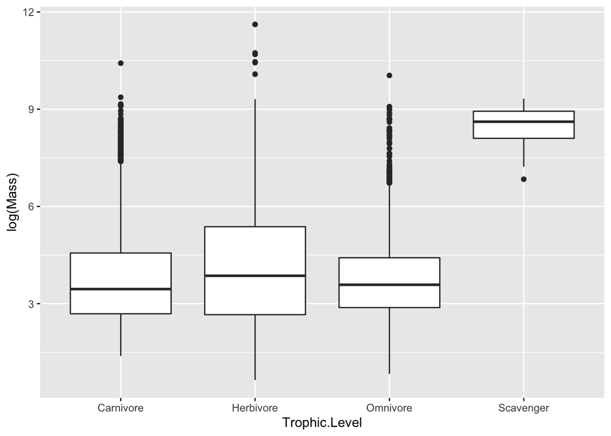

```r
#Take out the N/A's
d <- na.omit(d)

#Plot Trophic Level and Migration in correlation to body mass (Mass)
p1 <- ggplot(data = d, aes(x = Trophic.Level, y = log(Mass))) + geom_boxplot()
p1
```

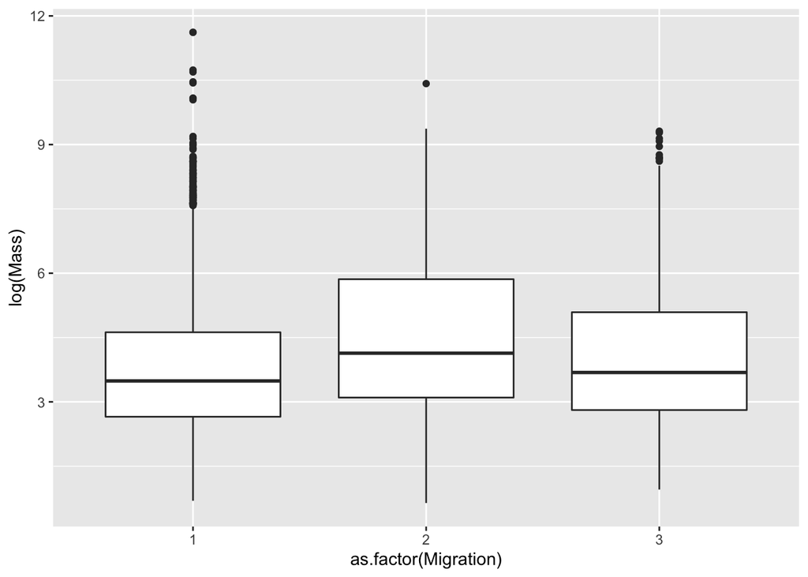

```r
p2 <- ggplot(data = d, aes(x = as.factor(Migration), y = log(Mass))) + geom_boxplot()
p2
```

• Also, you will want to convert the variable Migration (which is scored as a number: “1”, “2”, or “3”) from class numeric to either being classified as a factor or as a character (string) variable.

```r
#make the factor migration a new column in the original data
d <- d %>% mutate(Migration = as.factor(Migration), logMass = log(Mass))
```

## Step 2

• Run linear models using the lm() function to look at the relationship between log(Mass) and Trophic.Level and between log(Mass) and Migration.

```r
#Create linear models
mod1 <- lm(logMass ~ Trophic.Level, data = d)
mod1
```

```
##
## Call:
## lm(formula = logMass ~ Trophic.Level, data = d)
##
## Coefficients:
##            (Intercept)  Trophic.LevelHerbivore   Trophic.LevelOmnivore
##                3.80548                 0.26012                 0.01616
## Trophic.LevelScavenger
##                4.63475
```

```r
mod2 <- lm(logMass ~ Migration, data = d)
mod2
```

```
##
## Call:
## lm(formula = logMass ~ Migration, data = d)
##
## Coefficients:
## (Intercept)   Migration2   Migration3
##      3.7767       0.7549       0.3388
```

```r
#Summarize the models
summary(mod1)
```

```
##
## Call:
## lm(formula = logMass ~ Trophic.Level, data = d)
##
## Residuals:
##     Min      1Q  Median      3Q     Max
## -3.4237 -1.1533 -0.3006  0.9000  7.5517
##
## Coefficients:
##                        Estimate Std. Error t value Pr(>|t|)
## (Intercept)             3.80548    0.01978 192.368  < 2e-16 ***
## Trophic.LevelHerbivore  0.26012    0.03418   7.611 2.95e-14 ***
## Trophic.LevelOmnivore   0.01616    0.04133   0.391    0.696
## Trophic.LevelScavenger  4.63475    0.34369  13.485  < 2e-16 ***
## ---
## Signif. codes:  0 '***' 0.001 '**' 0.01 '*' 0.05 '.' 0.1 ' ' 1
##
## Residual standard error: 1.535 on 10852 degrees of freedom
## Multiple R-squared:  0.0214, Adjusted R-squared:  0.02113
## F-statistic: 79.12 on 3 and 10852 DF,  p-value: < 2.2e-16
```

```r
summary(mod2)
```

```
##
## Call:
## lm(formula = logMass ~ Migration, data = d)
##
## Residuals:
##     Min      1Q  Median      3Q     Max
## -3.8897 -1.1740 -0.3047  0.9147  7.8406
##
## Coefficients:
##             Estimate Std. Error t value Pr(>|t|)
## (Intercept)  3.77670    0.01642 230.019  < 2e-16 ***
## Migration2   0.75488    0.04743  15.916  < 2e-16 ***
## Migration3   0.33879    0.05190   6.528 6.96e-11 ***
## ---
## Signif. codes:  0 '***' 0.001 '**' 0.01 '*' 0.05 '.' 0.1 ' ' 1
##
## Residual standard error: 1.532 on 10853 degrees of freedom
## Multiple R-squared:  0.02484,    Adjusted R-squared:  0.02466
## F-statistic: 138.2 on 2 and 10853 DF,  p-value: < 2.2e-16
```

• Examine the output of the resultant linear models.

```r
mt <- aov(data = d, logMass ~ Trophic.Level)
summary(mt)
```

```
##                  Df Sum Sq Mean Sq F value Pr(>F)
## Trophic.Level     3    559  186.30   79.12 <2e-16 ***
## Residuals     10852  25553    2.35
## ---
## Signif. codes:  0 '***' 0.001 '**' 0.01 '*' 0.05 '.' 0.1 ' ' 1
```

```r
mt2 <- aov(data = d, logMass ~ Migration)
summary(mt2)
```

```
##                Df Sum Sq Mean Sq F value Pr(>F)
## Migration       2    649   324.4   138.2 <2e-16 ***
## Residuals   10853  25463     2.3
## ---
## Signif. codes:  0 '***' 0.001 '**' 0.01 '*' 0.05 '.' 0.1 ' ' 1
```

**Question:** Given the regression coefficients returned for your Migration model, which Migration categor(ies) are different than the reference level?  
**Answer:** Reference levels 2 & 3 are difference from the original reference level that can be seen in the summary of the original model (mt2)

**Question:** What level is the reference level?  
**Answer:** The original reference level is reference level 1.

```r
#produce intial model for comparison
summary(mt2)
```

```
##                Df Sum Sq Mean Sq F value Pr(>F)
## Migration       2    649   324.4   138.2 <2e-16 ***
## Residuals   10853  25463     2.3
## ---
## Signif. codes:  0 '***' 0.001 '**' 0.01 '*' 0.05 '.' 0.1 ' ' 1
```

• Relevel and assess differences among the remaining pair of Migration categories.

```r
#present levels
levels(d$Migration)
```

```
## [1] "1" "2" "3"
```

```r
#relevel 1
d <- d %>% mutate(Migration = relevel(Migration, ref = 1))
relevel_m1 <- lm(data = d, logMass ~ Migration)
summary(relevel_m1)
```

```
##
## Call:
## lm(formula = logMass ~ Migration, data = d)
##
## Residuals:
##     Min      1Q  Median      3Q     Max
## -3.8897 -1.1740 -0.3047  0.9147  7.8406
##
## Coefficients:
##             Estimate Std. Error t value Pr(>|t|)
## (Intercept)  3.77670    0.01642 230.019  < 2e-16 ***
## Migration2   0.75488    0.04743  15.916  < 2e-16 ***
## Migration3   0.33879    0.05190   6.528 6.96e-11 ***
## ---
## Signif. codes:  0 '***' 0.001 '**' 0.01 '*' 0.05 '.' 0.1 ' ' 1
##
## Residual standard error: 1.532 on 10853 degrees of freedom
## Multiple R-squared:  0.02484,    Adjusted R-squared:  0.02466
## F-statistic: 138.2 on 2 and 10853 DF,  p-value: < 2.2e-16
```

```r
#relevel 2
d <- d %>% mutate(Migration = relevel(Migration, ref = 2))
relevel_m2 <- lm(data = d, logMass ~ Migration)
summary(relevel_m2)
```

```
##
## Call:
## lm(formula = logMass ~ Migration, data = d)
##
## Residuals:
##     Min      1Q  Median      3Q     Max
## -3.8897 -1.1740 -0.3047  0.9147  7.8406
##
## Coefficients:
##             Estimate Std. Error t value Pr(>|t|)
## (Intercept)  4.53158    0.04450  101.84  < 2e-16 ***
## Migration1  -0.75488    0.04743  -15.92  < 2e-16 ***
## Migration3  -0.41609    0.06636   -6.27 3.74e-10 ***
## ---
## Signif. codes:  0 '***' 0.001 '**' 0.01 '*' 0.05 '.' 0.1 ' ' 1
##
## Residual standard error: 1.532 on 10853 degrees of freedom
## Multiple R-squared:  0.02484,    Adjusted R-squared:  0.02466
## F-statistic: 138.2 on 2 and 10853 DF,  p-value: < 2.2e-16
```

```r
#relevel 3
d <- d %>% mutate(Migration = relevel(Migration, ref = 3))
relevel_m3 <- lm(data = d, logMass ~ Migration)
summary(relevel_m3)
```

```
##
## Call:
## lm(formula = logMass ~ Migration, data = d)
##
## Residuals:
##     Min      1Q  Median      3Q     Max
## -3.8897 -1.1740 -0.3047  0.9147  7.8406
##
## Coefficients:
##             Estimate Std. Error t value Pr(>|t|)
## (Intercept)  4.11549    0.04923  83.594  < 2e-16 ***
## Migration2   0.41609    0.06636   6.270 3.74e-10 ***
## Migration1  -0.33879    0.05190  -6.528 6.96e-11 ***
## ---
## Signif. codes:  0 '***' 0.001 '**' 0.01 '*' 0.05 '.' 0.1 ' ' 1
##
## Residual standard error: 1.532 on 10853 degrees of freedom
## Multiple R-squared:  0.02484,    Adjusted R-squared:  0.02466
## F-statistic: 138.2 on 2 and 10853 DF,  p-value: < 2.2e-16
```

## Step 3

• Conduct a post-hoc Tukey Honest Significant Differences test to also evaluate which Migration categories differ “significantly” from one another (see Module 20).

```r
mig <- aov(data = d, logMass ~ Migration )
posthoc <- TukeyHSD(mig, which = "Migration", ordered = TRUE, conf.level = 0.95)
posthoc
```

```
##   Tukey multiple comparisons of means
##     95% family-wise confidence level
##     factor levels have been ordered
##
## Fit: aov(formula = logMass ~ Migration, data = d)
##
## $Migration
##          diff       lwr       upr p adj
## 3-1 0.3387925 0.2171436 0.4604413     0
## 2-1 0.7548837 0.6437092 0.8660582     0
## 2-3 0.4160912 0.2605413 0.5716411     0
```

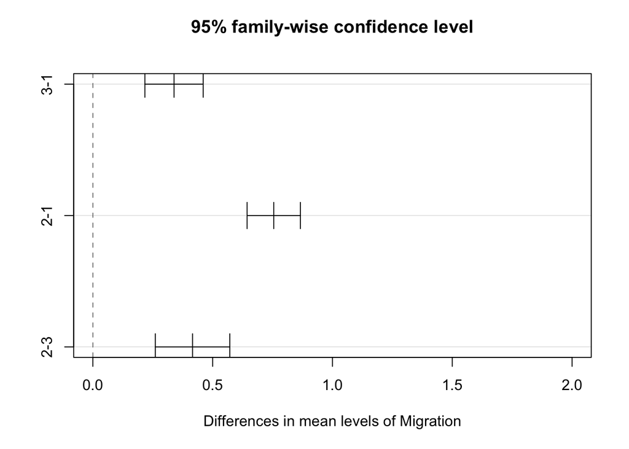

```r
plot(posthoc, xlim = c(0, 2))
```

## Step 4

• Use a permutation approach to inference to generate a null distribution of F statistic values for the model of log(Mass) in relation to Trophic.Level and calculate a p value for your original F statistic. You can do this either by programming your own permutation test (e.g., by shuffling values for the predictor or response variable among observations and calculating an F statistic for each replicate) or by using the {infer} workflow and setting calculate(stat=“F”).

```r
og_f <- aov(log(Mass) ~ Trophic.Level, data = d) %>%
  tidy() %>% #create a nice table of summary results
  filter(term=="Trophic.Level") #filter summary results

og_f
```

```
## # A tibble: 1 × 6
##   term             df sumsq meansq statistic  p.value
##   <chr>         <dbl> <dbl>  <dbl>     <dbl>    <dbl>
## 1 Trophic.Level     3  559.   186.      79.1 1.26e-50
```

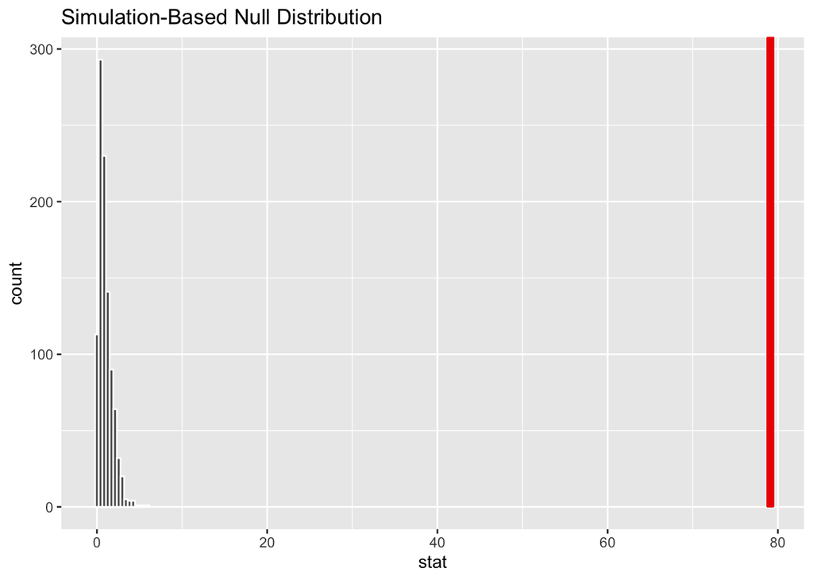

```r
perm_f <- d %>% specify(logMass ~ Trophic.Level)%>%
  hypothesize(null = "independence")%>%
  generate(reps = 1000, type = "permute")%>%
  calculate(stat = "F")

visualize(perm_f) + shade_p_value(obs_stat = og_f$statistic, direction = "greater")
```

```r
p_value <- perm_f %>% get_p_value(obs_stat = og_f$statistic, direction = "greater")
p_value
```

```
## # A tibble: 1 × 1
##   p_value
##     <dbl>
## 1       0
```

```r
og_f$p.value
```

```
## [1] 1.264878e-50
```